# EWMA chart with estimated in-control state

## Using normality assumptions

The following is an illustration for EWMA charts, assuming that all observations are normally distributed.

Based on \(n\) past in-control observations \(X_{-n},\dots,X_{-1}\), the in-control mean and standard deviation can be estimated by the sample mean, \(\hat \mu\), and sample standard deviation, \(\hat \sigma\). For new observations \(X_1,X_2,\dots\), an EWMA chart based on these estimated parameters is defined by \[ M_0=0, \quad M_t=\lambda \frac{X_t-\hat \mu}{\hat \sigma}+(1-\lambda) M_{t-1} \]

The following generates a data set of past observations (replace this with your observed past data).

```r
X <-  rnorm(250)
```

Next, we initialise the chart and compute the estimates needed for running the chart - in this case \(\hat \mu\) and \(\hat \sigma\).

```r
library(spcadjust)
chart <- new("SPCEWMA",model=SPCModelNormal(Delta=0),lambda=0.1);
xihat <- xiofdata(chart,X)
str(xihat)
```

```
## List of 3
##  $ mu: num 0.0251
##  $ sd: num 1.05
##  $ m : int 250
```

## Calibrating the chart to a given average run length (ARL)

We now compute a threshold that with roughly 90% probability results in an average run length of at least 100 in control. This is based on parametric resampling assuming normality of the observations.

```r
cal <- SPCproperty(data=X,nrep=50,
            property="calARL",chart=chart,params=list(target=100),quiet=TRUE)
cal
```

```
## 90 % CI: A threshold of +/- 0.5342 gives an in-control ARL of at
##   least 100.
## Unadjusted result:  0.4928
## Based on  50 bootstrap repetitions.
```

You should increase the number of bootstrap replications (the argument nrep) for real applications.

## Run the chart

Next, we run the chart with new observations that are in-control.

```r
newX <- rnorm(100)
S <- runchart(chart, newdata=newX,xi=xihat)
```

Then we plot the data and the chart.

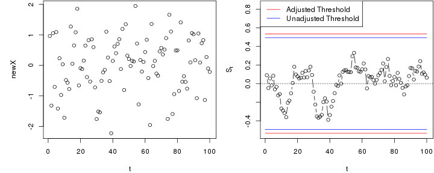

```r
par(mfrow=c(1,2),mar=c(4,5,0.1,0.1))
plot(newX,xlab="t")
plot(S,ylab=expression(S[t]),xlab="t",type="b",ylim=range(-cal@res,S,cal@res+0.3,cal@raw))
lines(c(0,100),rep(cal@res,2),col="red")
lines(c(0,100),rep(cal@raw,2),col="blue")
abline(0,0,lty=3)
lines(c(0,100),rep(-cal@res,2),col="red")
lines(c(0,100),rep(-cal@raw,2),col="blue")
legend("topleft",c("Adjusted Threshold","Unadjusted Threshold"),col=c("red","blue"),lty=1)
```

In the next example, the chart is run with data that are out-of-control from time 51 and onwards.

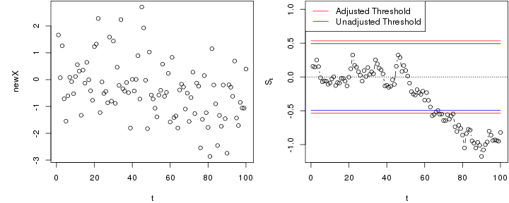

```r
newX <- rnorm(100,mean=c(rep(0,50),rep(-1,50)))
S <- runchart(chart, newdata=newX,xi=xihat)
```